# Panicum hallii microbiome

```r
library(vegan)
```

```r
map2 <- map %>% inner_join(info, by = "SampleID") %>%
  mutate(SampleID = gsub("\\.fastq\\.gz", "", RunID))
```

```
Column `SampleID` joining factors with different levels, coercing to character vector
```

| SampleID | BarcodeSequence | sampleID | itagger.name | Genotype | Species | Compartment | Resourse | Trt | Array | Intensity | Columnname | RunID |
| --- | --- | --- | --- | --- | --- | --- | --- | --- | --- | --- | --- | --- |
| 11874.1.223340.CTGTCATGAGT | NA | FCM.32.RE | FCM_32_RE_2017 | FIL2 | filipes | RE | greenhouse | control | FCM_32_RE_2017 | FCM_32_RE_2017 | FCM_32_RE_2017 | 11874.1.223340.CTGTCATGAGT.fastq.gz |
| 11874.1.223340.ATCATGTCAGT | NA | FCM.32.RE | FCM_32_RE_2017_2 | FIL2 | filipes | RE | greenhouse | control | FCM_32_RE_2017_2 | FCM_32_RE_2017_2 | FCM_32_RE_2017_2 | 11874.1.223340.ATCATGTCAGT.fastq.gz |
| 11874.1.223340.ATCAGTGTCAC | NA | FCM.34.RE | FCM_34_RE_2017 | FIL2 | filipes | RE | greenhouse | control | FCM_34_RE_2017 | FCM_34_RE_2017 | FCM_34_RE_2017 | 11874.1.223340.ATCAGTGTCAC.fastq.gz |
| 11874.1.223340.GATGCAGTCAC | NA | FCM.34.RE | FCM_34_RE_2017_2 | FIL2 | filipes | RE | greenhouse | control | FCM_34_RE_2017_2 | FCM_34_RE_2017_2 | FCM_34_RE_2017_2 | 11874.1.223340.GATGCAGTCAC.fastq.gz |
| 11874.1.223340.CAGTCTGATGC | NA | FCM.36.RE | FCM_36_RE_2017_2 | FIL2 | filipes | RE | greenhouse | control | FCM_36_RE_2017_2 | FCM_36_RE_2017_2 | FCM_36_RE_2017_2 | 11874.1.223340.CAGTCTGATGC.fastq.gz |
| 11874.1.223340.TCTACGAGATG | NA | FCM.32.RS | FCM_32_RS_2017 | FIL2 | filipes | RS | greenhouse | control | FCM_32_RS_2017 | FCM_32_RS_2017 | FCM_32_RS_2017 | 11874.1.223340.TCTACGAGATG.fastq.gz |
| 11874.1.223340.AGATGTAGCTC | NA | FCM.34.RS | FCM_34_RS_2017 | FIL2 | filipes | RS | greenhouse | control | FCM_34_RS_2017 | FCM_34_RS_2017 | FCM_34_RS_2017 | 11874.1.223340.AGATGTAGCTC.fastq.gz |
| 11874.1.223340.ACGTCGACTGA | NA | FFM.41.RE | FFM_41_RE_2017 | FIL2 | filipes | RE | greenhouse | fil_microbiome | FFM_41_RE_2017 | FFM_41_RE_2017 | FFM_41_RE_2017 | 11874.1.223340.ACGTCGACTGA.fastq.gz |
| 11874.1.223340.GTCGCTCATGA | NA | FFM.41.RE | FFM_41_RE_2017_2 | FIL2 | filipes | RE | greenhouse | fil_microbiome | FFM_41_RE_2017_2 | FFM_41_RE_2017_2 | FFM_41_RE_2017_2 | 11874.1.223340.GTCGCTCATGA.fastq.gz |
| 11874.1.223340.GAGTAGATCAC | NA | FFM.46.RE | FFM_46_RE_2017 | FIL2 | filipes | RE | greenhouse | fil_microbiome | FFM_46_RE_2017 | FFM_46_RE_2017 | FFM_46_RE_2017 | 11874.1.223340.GAGTAGATCAC.fastq.gz |

[output cut: 68 more lines]

Let’s try to get a feeling for what patterns are falling out of the data. We can do a PCoA to figure out if there are clustering patterns among variables in the data.

```r
pPC <- tidy_pcoa(ph_data %>% select(otu, Compartment, Genotype, Species, SampleID, Trt, logRA, Resource, Intensity, depth), otus = "otu", keep_loadings = T, value = "logRA")
```

```
Gathering metadata
Removing the column otu from the metadata.
Converting to wide table.
```

From what I remember, soil was collected from 2 sites. Hallii plants found growing there at the sites had their microbiomes collected and sequenced. Soil from the site was brought back to the greenhouse and used to inoculate plants. Let’s first see if can see any patterns differentiating nature from the greenhouse.

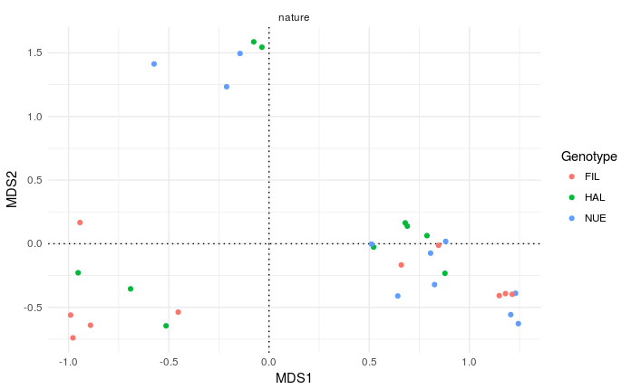

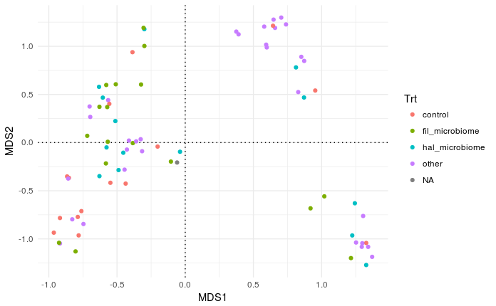

Again, there is no clear pattern for plants with a fil microbiome or a hal microbiome. I would definately expect a pattern in that regard. I just do not see one.